# Self-supervised representation audit: SimCLR on industrial castings

CST 620, Week 3. Can SimCLR pretraining replace expensive manual labels for defect inspection? Data: Kaggle casting product images (`casting_512x512`, 1,300 un-augmented originals), standing in for wafer inspection.

**This notebook only reads `results/` and `weights/`.** It trains nothing and scores nothing; every number was produced by the pipeline (`data.py`, `check_splits.py`, `train_ssl.py`, `baselines.py`, `eval.py`, `contaminated.py`). Test was scored exactly once (`results/eval.lock`).

```python
import json
from pathlib import Path
import hashlib
import pandas as pd
from IPython.display import Image, Markdown, display

R, W = Path("results"), Path("weights")          # the only folders this notebook reads
pd.set_option("display.precision", 3)

def load(name):
    """Read a JSON file from results/."""
    return json.loads((R / name).read_text())

def show(name, width=900):
    """Display a PNG from results/."""
    display(Image(filename=str(R / name), width=width))

def ms(s):
    """mean +/- sample std over draws (a single draw prints the value only)."""
    return f"{s.mean():.3f}" if len(s) < 2 else f"{s.mean():.3f} +/- {s.std(ddof=1):.3f}"

lock = load("eval.lock")
manifest = load("frozen_manifest.json")
checked = {k: v for k, v in manifest["files"].items() if v["path"].replace("\\", "/").split("/")[0] in ("weights", "results")}
ok = all(hashlib.sha256((Path(v["path"])).read_bytes()).hexdigest() == v["sha256"] for v in checked.values())
print(f"eval.lock: {lock['status']} at {lock['at_utc']} (manifest frozen {manifest['frozen_at_utc']})")
print(f"frozen weights/results files re-hashed here: {len(checked)}, all match: {ok}")
```

```
eval.lock: complete at 2026-09-29T01:02:49+00:00 (manifest frozen 2026-09-29T00:56:25+00:00)
frozen weights/results files re-hashed here: 12, all match: True
```

## 1. Data audit

### 1a. The provided train/test split leaks (casting_data/, excluded)

The dataset ships a 300 px set with its own train/test split. Its images are pre-augmented copies that cannot be traced to a source image, so it is excluded; `audit_source.py` measures how much its own split leaks.

```python
src = load("source_audit.json")
pd.DataFrame(src["checks"]).set_index("check")
```

| check | count | total | pct |
| --- | --- | --- | --- |
| provided test: MD5 match in provided train | 64 | 715 | 9.0 |
| provided test: 256-bit neighbor <= 24 in provided train | 330 | 715 | 46.2 |
| 300 px (all): 256-bit neighbor <= 24 in 1,300 originals | 50 | 7348 | 0.7 |
| of which provided train | 43 | 6633 | 0.6 |
| of which provided test | 7 | 715 | 1.0 |

### 1b. Near-duplicate grouping: three settings

A near-duplicate pair is the same casting photographed again; connected components become `group_id`, and a group never spans two splits. The 64-bit hash chains almost everything into one group. Identity-only 256-bit hashing missed 180-degree rotated and mirrored re-shots, so the final grouping takes the minimum Hamming distance over 8 orientations.

```python
g = load("grouping_stats.json")
pd.DataFrame(g["settings"]).rename_axis(f"{g['n_images']} images")
```

| 1300 images | 64-bit <= 10 | 256-bit <= 24 | 256-bit 8-orient <= 24 |
| --- | --- | --- | --- |
| images linked | 1283 | 241 | 685 |
| multi-image groups | 22 | 106 | 184 |
| largest group | 1183 | 6 | 50 |
| groups mixing ok+defect | 3 | 0 | 3 |

### 1c. Twin layers: what each fix removed

```python
pre = load("pre_fix/rotated_twins.json")["counts"]
now = load("rotated_twins.json")["counts"]
res = load("residual_twins.json")
strata = load("test_strata.json")
layers = pd.DataFrame([
    {"layer": "rotated/mirrored twin in train (identity grouping, pre-fix split)", "val": pre["val"]["TOTAL with twin"], "test": pre["test"]["TOTAL with twin"]},
    {"layer": "rotated/mirrored twin in train (8-orientation grouping, final split)", "val": now["val"]["TOTAL with twin"], "test": now["test"]["TOTAL with twin"]},
    {"layer": "near stratum: feature 1-NN partner within 8-orient pHash <= 40", "val": res["summary"][0]["val images"], "test": strata["n_near"]},
    {"layer": "clean stratum", "val": res["summary"][1]["val images"], "test": strata["n_clean"]},
]).set_index("layer")
display(layers)
print("VAL random-init 1-NN accuracy by stratum (residual twin check):")
pd.DataFrame(res["summary"])
```

| layer | val | test |
| --- | --- | --- |
| rotated/mirrored twin in train (identity grouping, pre-fix split) | 44 | 101 |
| rotated/mirrored twin in train (8-orientation grouping, final split) | 0 | 0 |
| near stratum: feature 1-NN partner within 8-orient pHash <= 40 | 35 | 58 |
| clean stratum | 139 | 202 |

```
VAL random-init 1-NN accuracy by stratum (residual twin check):
```

|  | distance | stratum | val images | 1-NN acc |
| --- | --- | --- | --- | --- |
| 0 | partner = nearest train image by random-init c... | near (<= 40) | 35 | 1.000 |
| 1 | partner = nearest train image by random-init c... | clean (> 40) | 139 | 0.799 |
| 2 | nearest train image by 8-orient pHash (test st... | near (<= 40) | 124 | 0.847 |
| 3 | nearest train image by 8-orient pHash (test st... | clean (> 40) | 50 | 0.820 |

```
Pre-fix split: val images and their rotated train twins (same casting, 180 deg / mirrored)
```

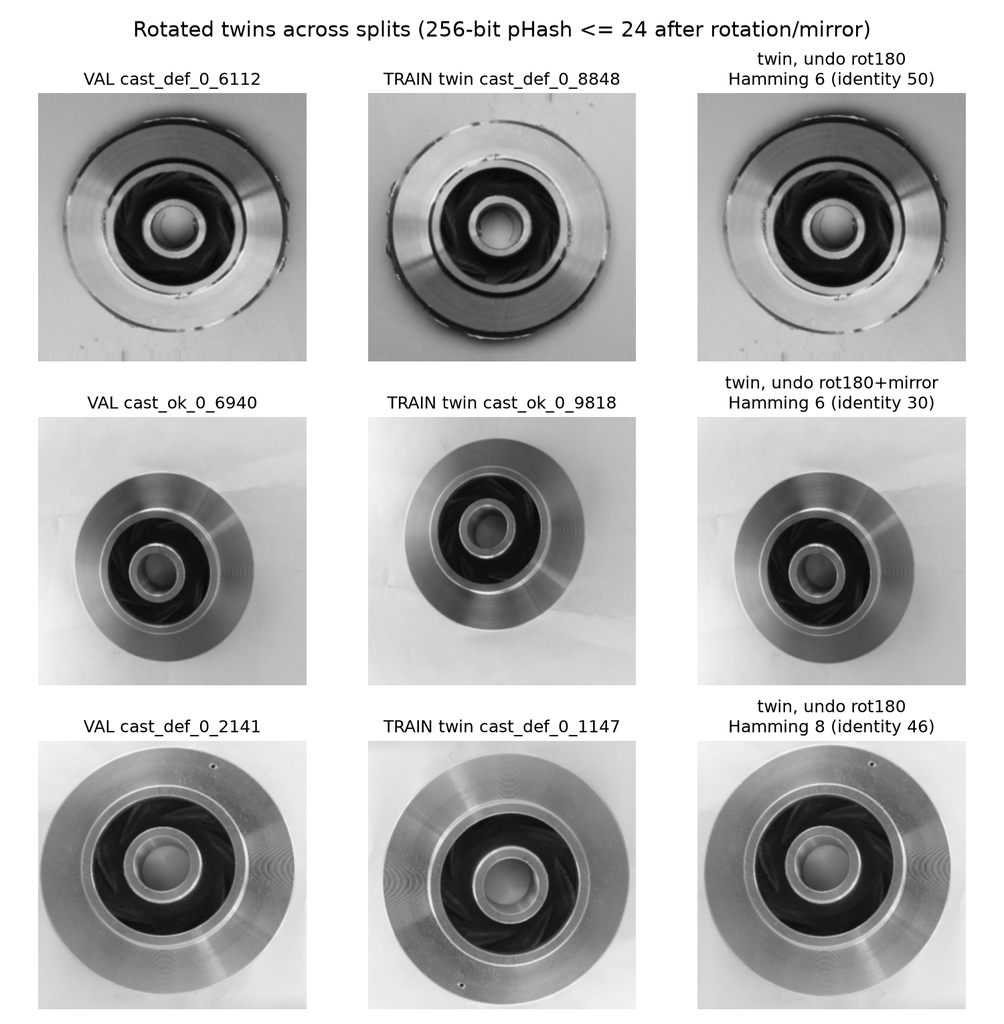

```
Final split, VAL: closest val / nearest-train pairs that survive 8-orientation grouping
```

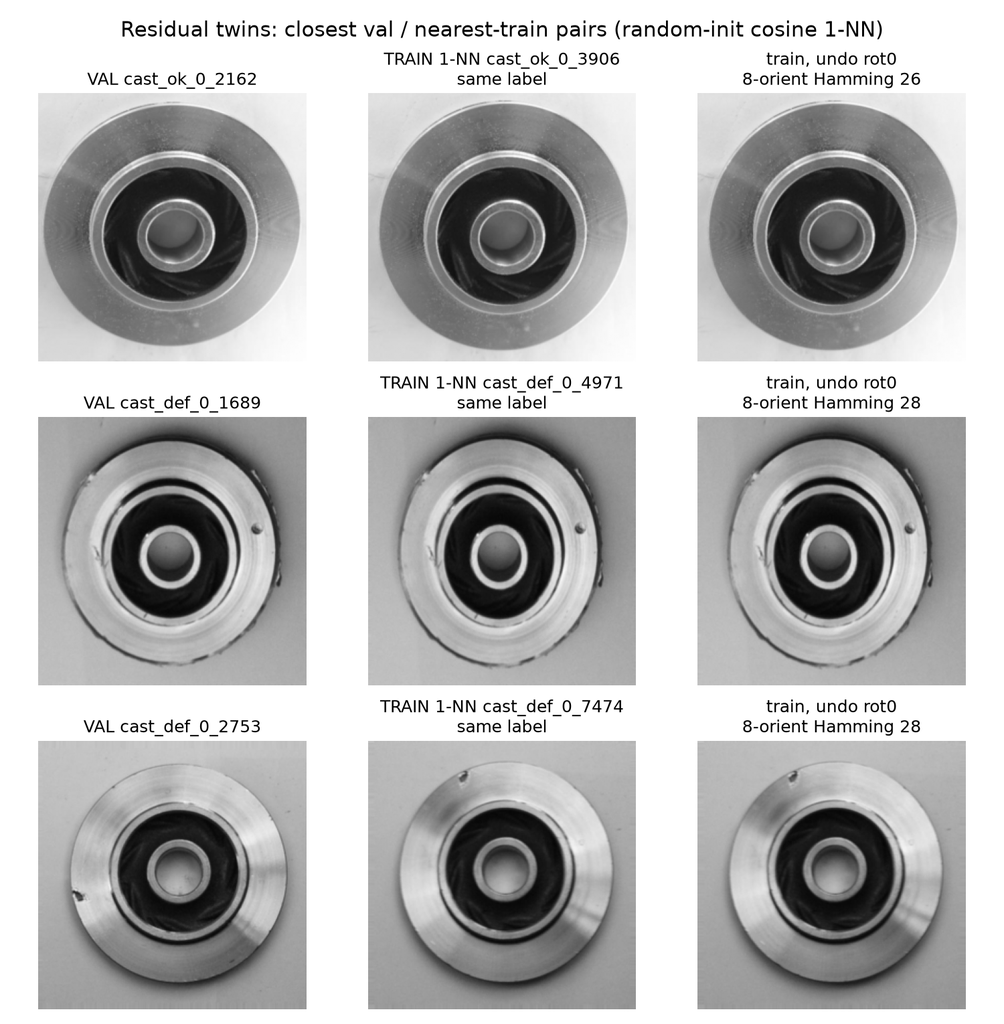

```python
print("Pre-fix split: val images and their rotated train twins (same casting, 180 deg / mirrored)")
show("pre_fix/rotated_twins.png", 700)
print("Final split, VAL: closest val / nearest-train pairs that survive 8-orientation grouping")
show("residual_twins.png", 700)
```

### 1d. check_splits.py: the clean pretraining list passes, the CONTAMINATED list fails

```python
clean, bad = load("check_splits.json"), load("check_splits_pretrain_contaminated.json")
t = pd.DataFrame(clean["checks"]).set_index("check")[["count", "status"]]
t = t.join(pd.DataFrame(bad["checks"]).set_index("check")[["count", "status"]], rsuffix=" (CONTAMINATED list)")
print(f"split sizes: {clean['split_sizes']}")
print(f"clean list: {clean['n_checks'] - clean['n_fail']}/{clean['n_checks']} PASS;  CONTAMINATED list: {bad['n_fail']} FAIL")
t
```

```
split sizes: {'train': 866, 'val': 174, 'test': 260}
clean list: 18/18 PASS;  CONTAMINATED list: 3 FAIL
```

| check | count | status | count (CONTAMINATED list) | status (CONTAMINATED list) |
| --- | --- | --- | --- | --- |
| path shared train/val | 0 | PASS | 0 | PASS |
| path shared train/test | 0 | PASS | 0 | PASS |
| path shared val/test | 0 | PASS | 0 | PASS |
| md5 shared train/val | 0 | PASS | 0 | PASS |
| md5 shared train/test | 0 | PASS | 0 | PASS |
| md5 shared val/test | 0 | PASS | 0 | PASS |
| group_id shared train/val | 0 | PASS | 0 | PASS |
| group_id shared train/test | 0 | PASS | 0 | PASS |
| group_id shared val/test | 0 | PASS | 0 | PASS |
| split paths missing from hashes.npz | 0 | PASS | 0 | PASS |
| 8-orient pHash pairs <= 24 train/val | 0 | PASS | 0 | PASS |
| 8-orient pHash pairs <= 24 train/test | 0 | PASS | 0 | PASS |
| 8-orient pHash pairs <= 24 val/test | 0 | PASS | 0 | PASS |
| pretrain paths not in train | 0 | PASS | 260 | FAIL |
| pretrain paths in val | 0 | PASS | 0 | PASS |
| pretrain paths in test | 0 | PASS | 260 | FAIL |
| pretrain paths missing from hashes.npz | 0 | PASS | 0 | PASS |
| 8-orient pHash pairs <= 24 pretrain/test | 0 | PASS | 512 | FAIL |

## 2. Augmentations

Castings are round and shot from the top, so views use 0-360 degree rotation, flips, brightness/contrast jitter and a random crop. The first version (crop scale 0.8-1.0, free aspect ratio, rare blur) was changed to crop scale 0.9-1.0, square crops (castings stay round) and no blur, so small pits and cracks survive every view. Rotated corners are filled with the median border pixel, not black.

```
BEFORE: crop 0.8-1.0, aspect 3/4-4/3, blur p=0.1
```

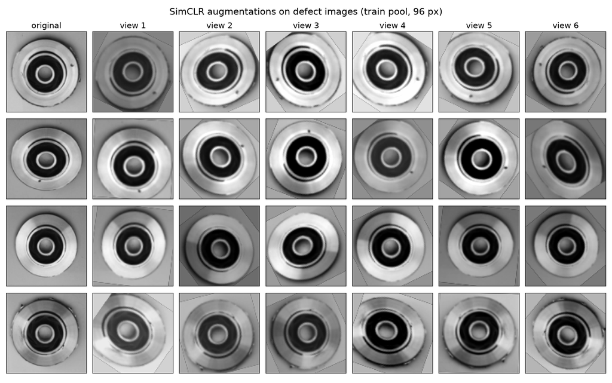

```
AFTER (used): crop 0.9-1.0, square, no blur
```

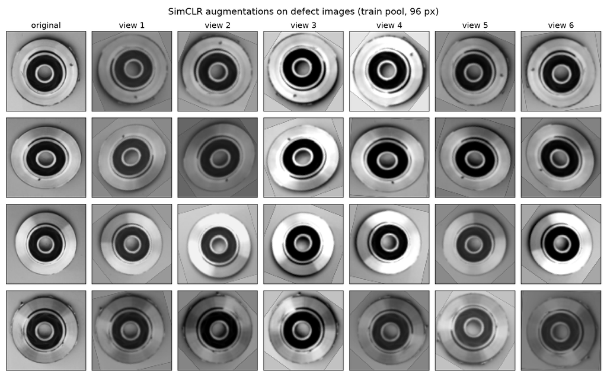

```python
print("BEFORE: crop 0.8-1.0, aspect 3/4-4/3, blur p=0.1")
show("aug_check_before.png", 800)
print("AFTER (used): crop 0.9-1.0, square, no blur")
show("aug_check.png", 800)
```

## 3. SimCLR pretraining

ResNet-18 from scratch (`weights=None`), 512-d encoder, 2-layer projection head (512-512-128) used for training only, NT-Xent with cosine similarity. 96 px grayscale, CPU. The val monitor is **leave-one-group-out** k-NN (k=5): plain leave-one-out let rotated twins inside val vote for each other.

```python
sweep = load("tau_sweep.json")
print(f"tau sweep: {sweep['config']['sweep_epochs']} epochs each, batch {sweep['batch_size']}, "
      f"{sweep['negatives_per_anchor']} negatives per anchor; rule: {sweep['rule']}")
pd.DataFrame({f"tau {t}": {"val_knn epoch 0": r["history"][0]["val_knn"], "val_knn final": r["final_val_knn"],
                           "proj_std final": r["final_proj_std"], "sec/epoch": r["seconds_per_epoch"]}
              for t, r in sweep["runs"].items()}).T.assign(picked=lambda d: ["<--" if float(i.split()[1]) == sweep["best_tau"] else "" for i in d.index])
```

```
tau sweep: 3 epochs each, batch 64, 126 negatives per anchor; rule: max final val leave-one-group-out k-NN (k=5, cosine); tie -> higher proj_std
```

|  | val_knn epoch 0 | val_knn final | proj_std final | sec/epoch | picked |
| --- | --- | --- | --- | --- | --- |
| tau 0.1 | 0.667 | 0.563 | 0.079 | 40.7 |  |
| tau 0.2 | 0.667 | 0.563 | 0.068 | 40.8 |  |
| tau 0.5 | 0.667 | 0.598 | 0.074 | 39.5 | <-- |

```
full run: tau 0.5, 10 epochs, batch 64, 126 negatives per anchor, 42.5 s/epoch; last epoch kept
epoch 0 (random init): val_knn 0.6667 leave-one-group-out, 0.8448 plain leave-one-out (inflated by twins)
final: val_knn 0.6954  (+2.9 points vs epoch 0)
```

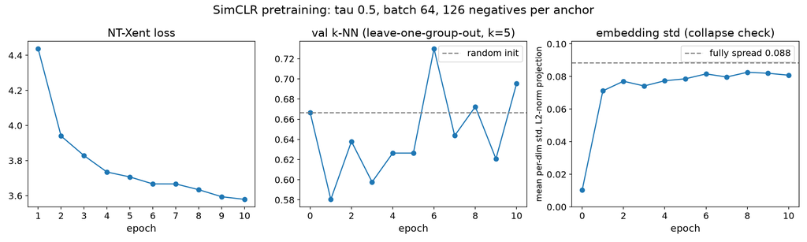

| epoch | loss | val_knn | proj_std | seconds |
| --- | --- | --- | --- | --- |
| 0 | NaN | 0.667 | 0.010 | 0.0 |
| 1 | 4.437 | 0.581 | 0.071 | 43.8 |
| 2 | 3.940 | 0.638 | 0.077 | 42.8 |
| 3 | 3.829 | 0.598 | 0.074 | 41.9 |
| 4 | 3.735 | 0.626 | 0.077 | 46.3 |
| 5 | 3.707 | 0.626 | 0.079 | 42.2 |
| 6 | 3.667 | 0.730 | 0.082 | 45.5 |
| 7 | 3.667 | 0.644 | 0.080 | 39.9 |
| 8 | 3.634 | 0.672 | 0.083 | 39.1 |
| 9 | 3.594 | 0.621 | 0.082 | 43.6 |
| 10 | 3.579 | 0.695 | 0.081 | 40.1 |

```python
h = load("pretrain_history.json")
hist = pd.DataFrame(h["history"]).set_index("epoch")
print(f"full run: tau {h['config']['tau']}, {len(hist) - 1} epochs, batch {h['batch_size']}, "
      f"{h['negatives_per_anchor']} negatives per anchor, {h['seconds_per_epoch']} s/epoch; last epoch kept")
print(f"epoch 0 (random init): val_knn {hist.loc[0, 'val_knn']:.4f} leave-one-group-out, "
      f"{hist.loc[0, 'val_knn_loo']:.4f} plain leave-one-out (inflated by twins)")
print(f"final: val_knn {hist['val_knn'].iloc[-1]:.4f}  ({100 * (hist['val_knn'].iloc[-1] - hist.loc[0, 'val_knn']):+.1f} points vs epoch 0)")
show("pretrain_curve.png", 950)
hist[["loss", "val_knn", "proj_std", "seconds"]]
```

## 4. Validation selection (VAL only, not the reported result)

k, C, the anomaly option, thresholds, tau, and the supervised learning rate and best epoch were all chosen on the 174-image val split, so these numbers are optimistic. Label budgets per class: 10, 25, 50 (3 draws each) and all; every method at a budget uses the same labeled images.

VAL selection results (selection only, not the reported result)

These are VALIDATION numbers. Val (174 images: 69 ok, 105 defect) chose k, C, the anomaly k, the threshold, and the supervised best epoch, so every number here is optimistic. The reported result is the single test run in eval.py.

Majority class (always 'defect') on val: 60.3%. One val image = 0.57 points.

VAL accuracy by labels per class (mean +/- std over 3 draws; 'all' = 1 draw)

| method | 10 | 25 | 50 | all |
| --- | --- | --- | --- | --- |
| SSL probe | 0.713 +/- 0.030 | 0.745 +/- 0.054 | 0.761 +/- 0.046 | 0.799 |
| SSL k-NN | 0.738 +/- 0.041 | 0.743 +/- 0.027 | 0.711 +/- 0.023 | 0.707 |
| random probe | 0.688 +/- 0.038 | 0.724 +/- 0.040 | 0.724 +/- 0.038 | 0.736 |
| random k-NN | 0.732 +/- 0.033 | 0.730 +/- 0.011 | 0.732 +/- 0.009 | 0.839 |
| supervised | 0.713 +/- 0.050 | 0.688 +/- 0.093 | 0.749 +/- 0.035 | 0.885 |

Flags (VAL)

- SSL, budget 10: k-NN beats probe by 2.5 points

- random, budget 10: k-NN beats probe by 4.4 points

- random, budget 25: k-NN beats probe by 0.6 points

- random, budget 50: k-NN beats probe by 0.8 points

- random, budget all: k-NN beats probe by 10.3 points

Budgets where the probe beats k-NN by > 10 points on VAL: 0. Budgets where k-NN beats the probe on VAL: 5.

Anomaly score (VAL)

Score = cosine distance of a val image to the labeled ok embeddings of the budget; the option (local k, all_ok, centroid) and the threshold (catch 95% of val defects) are chosen on val.

| encoder | budget | AUROC | false rejects at 95% defect recall | chosen option per draw |
| --- | --- | --- | --- | --- |
| ssl | 10 | 0.792 +/- 0.010 | 0.705 +/- 0.065 | 10/10/10 |
| ssl | 25 | 0.803 +/- 0.012 | 0.691 +/- 0.008 | all_ok/all_ok/all_ok |
| ssl | 50 | 0.794 +/- 0.014 | 0.705 +/- 0.017 | all_ok/all_ok/all_ok |
| ssl | all | 0.787 | 0.739 | all_ok |
| random | 10 | 0.596 +/- 0.048 | 0.894 +/- 0.042 | centroid/10/5 |
| random | 25 | 0.607 +/- 0.030 | 0.899 +/- 0.014 | all_ok/all_ok/20 |
| random | 50 | 0.604 +/- 0.017 | 0.879 +/- 0.017 | all_ok/all_ok/all_ok |
| random | all | 0.717 | 0.449 | 1 |

Grid change after seeing val

Anomaly grid widened AFTER seeing val: added 'all_ok' (mean cosine distance to all labeled ok embeddings) and 'centroid' (cosine distance to the labeled ok centroid). Reason, as observed on the pre_logo run: with the 'all' budget (346 ok refs), k in {1, 5, 10, 20} only measures local distance; every val image, ok or defect, has a near ok neighbor (median nearest-ok distance ratio defect/ok = 1.01), so SSL val AUROC fell to 0.57 while a global distance gave about 0.79. At 10 per class the chosen k = 10 already averaged over every ok ref, i.e. it was already a global score. Because the grid change was made after looking at val, val AUROC for the anomaly score is extra optimistic; the test run is the check.

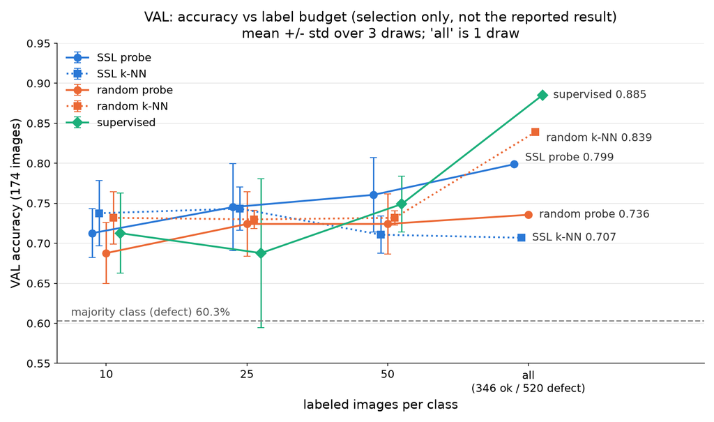

```python
text = (R / "val_selection.md").read_text()
display(Markdown(chr(10).join(l for l in text.splitlines() if not l.startswith("!["))))   # figure shown below
show("val_budget_curve.png", 900)
```

```python
sup = load("supervised_log.json")
print("Supervised baseline: learning rate chosen per budget on draw 0 (val accuracy)")
pd.DataFrame({b: {lr: c[lr]["val_acc"] for lr in c} | {"chosen": f'{sup["chosen_lr"][b]:g}'}
              for b, c in sup["lr_search"].items()}).T
```

```
Supervised baseline: learning rate chosen per budget on draw 0 (val accuracy)
```

|  | 0.0001 | 0.0003 | 0.001 | chosen |
| --- | --- | --- | --- | --- |
| 10 | 0.724 | 0.736 | 0.632 | 0.0003 |
| 25 | 0.736 | 0.701 | 0.73 | 0.0001 |
| 50 | 0.782 | 0.77 | 0.69 | 0.0001 |
| all | 0.885 | 0.81 | 0.81 | 0.0001 |

## 5. Test results (scored once, frozen choices)

All choices were hashed into `frozen_manifest.json` before test was opened. The near/clean strata were computed from test images and train features before any test label was read.

```
TEST: 260 images (104 ok, 156 defect); majority 60.0%; one image = 0.38 points
```

| budget method | 10 | 25 | 50 | all |
| --- | --- | --- | --- | --- |
| SSL probe | 0.621 +/- 0.002 | 0.676 +/- 0.056 | 0.738 +/- 0.042 | 0.912 |
| SSL k-NN | 0.656 +/- 0.025 | 0.681 +/- 0.023 | 0.638 +/- 0.044 | 0.758 |
| random probe | 0.619 +/- 0.038 | 0.658 +/- 0.028 | 0.676 +/- 0.028 | 0.769 |
| random k-NN | 0.626 +/- 0.021 | 0.655 +/- 0.049 | 0.662 +/- 0.050 | 0.877 |
| supervised | 0.636 +/- 0.024 | 0.564 +/- 0.036 | 0.668 +/- 0.027 | 0.835 |

```
flags:
  SSL, budget 10: k-NN beats probe by 3.6 points
  SSL, budget 25: k-NN beats probe by 0.5 points
  SSL, budget 50: probe beats k-NN by 10.0 points (> 10)
  SSL, budget all: probe beats k-NN by 15.4 points (> 10)
  random, budget 10: k-NN beats probe by 0.6 points
  random, budget all: k-NN beats probe by 10.8 points
```

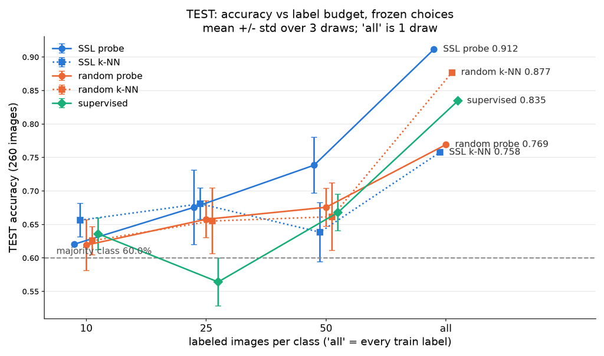

```python
tm = load("test_metrics.json")
c = tm["counts"]
print(f"TEST: {c['n']} images ({c['ok']} ok, {c['defect']} defect); majority {c['majority']:.1%}; one image = {100 / c['n']:.2f} points")
rows = []
for r in tm["frozen_draws"]:
    enc = {"ssl": "SSL", "random": "random"}[r["encoder"]]
    rows += [{"method": f"{enc} k-NN", "budget": r["budget"], **r["knn"]}, {"method": f"{enc} probe", "budget": r["budget"], **r["probe"]}]
rows += [{"method": "supervised", **r} for r in tm["supervised"]]
acc = pd.DataFrame(rows)
order = ["SSL probe", "SSL k-NN", "random probe", "random k-NN", "supervised"]
table = acc.pivot_table(index="method", columns="budget", values="acc", aggfunc=ms).loc[order, ["10", "25", "50", "all"]]
display(table)
print("flags:", *tm["flags"], sep="\n  ")
show("test_budget_curve.png", 900)
```

```python
print("Per-class recall on TEST (mean over draws): ok / defect")
rec = acc.groupby(["method", "budget"]).agg(ok=("recall_ok", "mean"), defect=("recall_defect", "mean"))
rec.assign(v=lambda d: d["ok"].map("{:.3f}".format) + " / " + d["defect"].map("{:.3f}".format))["v"].unstack().loc[order, ["10", "25", "50", "all"]]
```

```
Per-class recall on TEST (mean over draws): ok / defect
```

| budget method | 10 | 25 | 50 | all |
| --- | --- | --- | --- | --- |
| SSL probe | 0.369 / 0.788 | 0.503 / 0.791 | 0.622 / 0.816 | 0.904 / 0.917 |
| SSL k-NN | 0.465 / 0.784 | 0.545 / 0.771 | 0.458 / 0.759 | 0.625 / 0.846 |
| random probe | 0.497 / 0.701 | 0.465 / 0.786 | 0.490 / 0.799 | 0.644 / 0.853 |
| random k-NN | 0.362 / 0.801 | 0.449 / 0.793 | 0.474 / 0.786 | 0.837 / 0.904 |
| supervised | 0.372 / 0.812 | 0.481 / 0.620 | 0.439 / 0.821 | 0.712 / 0.917 |

```python
an = pd.DataFrame([{"encoder": r["encoder"], "budget": r["budget"], "draw": r["draw"], **r["anomaly"]} for r in tm["frozen_draws"]])
an["AUROC [95% CI, group bootstrap]"] = an.apply(lambda r: f"{r.auroc:.3f} [{r.auroc_ci95_group[0]:.3f}, {r.auroc_ci95_group[1]:.3f}]", axis=1)
an["false reject rate"] = an["false_rejects"] / c["ok"]
print("Anomaly score on TEST (frozen option and threshold chosen on val to catch 95% of val defects)")
an[["encoder", "budget", "draw", "option", "AUROC [95% CI, group bootstrap]", "missed_defects", "false_rejects",
    "false reject rate", "recall_defect", "recall_ok"]].set_index(["encoder", "budget", "draw"])
```

```
Anomaly score on TEST (frozen option and threshold chosen on val to catch 95% of val defects)
```

| encoder | budget | draw | option | AUROC [95% CI, group bootstrap] | missed_defects | false_rejects | false reject rate | recall_defect | recall_ok |
| --- | --- | --- | --- | --- | --- | --- | --- | --- | --- |
| ssl | 10 | 0 | 10 | 0.719 [0.592, 0.870] | 2 | 89 | 0.856 | 0.987 | 0.144 |
|  | 25 | 0 | all_ok | 0.733 [0.602, 0.863] | 11 | 79 | 0.760 | 0.929 | 0.240 |
|  | 50 | 0 | all_ok | 0.727 [0.598, 0.874] | 2 | 87 | 0.837 | 0.987 | 0.163 |
|  | 10 | 1 | 10 | 0.683 [0.558, 0.829] | 4 | 93 | 0.894 | 0.974 | 0.106 |
|  | 25 | 1 | all_ok | 0.673 [0.548, 0.832] | 4 | 92 | 0.885 | 0.974 | 0.115 |
|  | 50 | 1 | all_ok | 0.702 [0.573, 0.854] | 0 | 91 | 0.875 | 1.000 | 0.125 |
|  | 10 | 2 | 10 | 0.713 [0.580, 0.867] | 2 | 79 | 0.760 | 0.987 | 0.240 |
|  | 25 | 2 | all_ok | 0.739 [0.608, 0.876] | 5 | 80 | 0.769 | 0.968 | 0.231 |
|  | 50 | 2 | all_ok | 0.699 [0.571, 0.853] | 0 | 93 | 0.894 | 1.000 | 0.106 |
|  | all | 0 | all_ok | 0.706 [0.577, 0.862] | 2 | 89 | 0.856 | 0.987 | 0.144 |
| random | 10 | 0 | centroid | 0.669 [0.591, 0.759] | 10 | 84 | 0.808 | 0.936 | 0.192 |
|  | 25 | 0 | all_ok | 0.686 [0.599, 0.775] | 5 | 91 | 0.875 | 0.968 | 0.125 |
|  | 50 | 0 | all_ok | 0.689 [0.609, 0.763] | 7 | 86 | 0.827 | 0.955 | 0.173 |
|  | 10 | 1 | 10 | 0.622 [0.522, 0.702] | 7 | 92 | 0.885 | 0.955 | 0.115 |
|  | 25 | 1 | all_ok | 0.641 [0.559, 0.729] | 10 | 93 | 0.894 | 0.936 | 0.106 |
|  | 50 | 1 | all_ok | 0.657 [0.579, 0.745] | 12 | 86 | 0.827 | 0.923 | 0.173 |
|  | 10 | 2 | 5 | 0.656 [0.581, 0.759] | 9 | 87 | 0.837 | 0.942 | 0.163 |
|  | 25 | 2 | 20 | 0.621 [0.540, 0.705] | 6 | 89 | 0.856 | 0.962 | 0.144 |
|  | 50 | 2 | all_ok | 0.648 [0.566, 0.733] | 11 | 88 | 0.846 | 0.929 | 0.154 |
|  | all | 0 | 1 | 0.922 [0.855, 0.967] | 16 | 29 | 0.279 | 0.897 | 0.721 |

```python
print(f"Strata on TEST: near {tm['strata']['n_near']}, clean {tm['strata']['n_clean']}")
print(tm["strata"]["rule"])
st = acc.groupby(["method", "budget"])[["acc_near", "acc_clean"]].mean()
st.assign(v=lambda d: d["acc_near"].map("{:.3f}".format) + " / " + d["acc_clean"].map("{:.3f}".format))["v"].unstack().loc[order, ["10", "25", "50", "all"]]
```

```
Strata on TEST: near 58, clean 202
near = a test image whose nearest train image by random-init feature cosine is within 8-orientation 256-bit pHash distance <= 40; clean = every other test image.
```

| budget method | 10 | 25 | 50 | all |
| --- | --- | --- | --- | --- |
| SSL probe | 0.580 / 0.632 | 0.626 / 0.690 | 0.707 / 0.748 | 0.914 / 0.911 |
| SSL k-NN | 0.603 / 0.672 | 0.649 / 0.690 | 0.615 / 0.645 | 0.776 / 0.752 |
| random probe | 0.644 / 0.612 | 0.632 / 0.665 | 0.667 / 0.678 | 0.776 / 0.767 |
| random k-NN | 0.552 / 0.647 | 0.638 / 0.660 | 0.638 / 0.668 | 0.948 / 0.856 |
| supervised | 0.621 / 0.640 | 0.500 / 0.583 | 0.615 / 0.683 | 0.845 / 0.832 |

## 6. Embedding quality (TEST, frozen encoders)

Silhouette and Davies-Bouldin on one image per group (seed 42), so re-shots of one casting cannot pad a cluster. The t-SNE plot is a picture, not proof; the probe, k-NN and anomaly numbers are the proof.

|  | silhouette | davies_bouldin | n |
| --- | --- | --- | --- |
| SSL | 0.208 | 2.207 | 160 |
| random-init | 0.038 | 4.909 | 160 |
| supervised (all) | 0.243 | 1.482 | 160 |

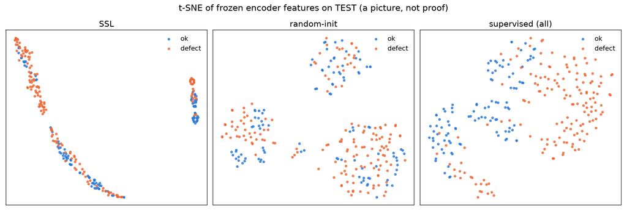

```python
display(pd.DataFrame(tm["embedding_quality"]).T.astype({"n": int}))
show("tsne.png", 1000)
```

## 7. CONTAMINATED control (leakage estimate)

**CONTAMINATED:** the SSL encoder was pretrained again with the same config on the train pool **plus the 260 test images**, then scored on test with the same frozen k, C, anomaly option and threshold. The gap (CONTAMINATED minus clean) estimates how much seeing test images during pretraining would inflate the SSL numbers.

```
CONTAMINATED pretraining: 10 epochs, tau 0.5, list splits\pretrain_contaminated.csv
CONTAMINATED minus clean on TEST (SSL encoder), mean +/- std over draws, in accuracy / AUROC units:
```

| budget | knn_acc_gap | probe_acc_gap | auroc_gap |
| --- | --- | --- | --- |
| 10 | -0.008 +/- 0.020 | 0.018 +/- 0.016 | -0.003 +/- 0.010 |
| 25 | -0.003 +/- 0.011 | -0.001 +/- 0.021 | -0.002 +/- 0.024 |
| 50 | 0.000 +/- 0.008 | -0.046 +/- 0.017 | -0.006 +/- 0.008 |
| all | 0.000 | 0.004 | -0.006 |

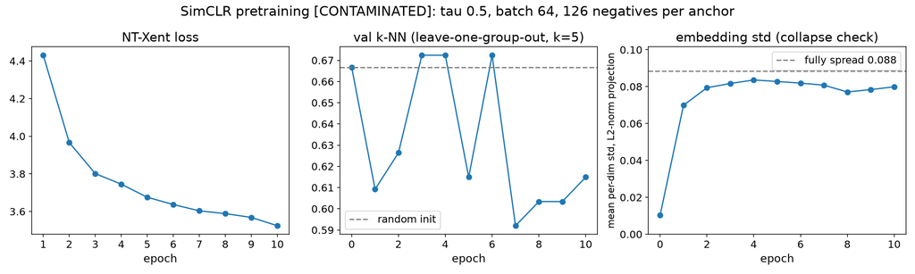

```python
gap = pd.DataFrame(load("contaminated/leakage_gap.json")["per_draw"])
ch = load("pretrain_history_contaminated.json")
print(f"CONTAMINATED pretraining: {len(ch['history']) - 1} epochs, tau {ch['config']['tau']}, list {ch['config']['pretrain_csv']}")
print("CONTAMINATED minus clean on TEST (SSL encoder), mean +/- std over draws, in accuracy / AUROC units:")
display(gap.groupby("budget", sort=False)[["knn_acc_gap", "probe_acc_gap", "auroc_gap"]].agg(ms))
show("pretrain_curve_contaminated.png", 950)
```

## 8. Limitations

- **Small evaluation sets.** Val has 174 images (one image = 0.57 points) and test 260 (0.38 points); AUROC confidence intervals are about +/- 0.13. Budget "all" is a single draw.
- **Weak pretraining by design of the compute budget.** CPU only: 96 px, 10 epochs, batch 64 (126 negatives per anchor), one seed. Published SimCLR uses hundreds of epochs and thousands of negatives; this measures SimCLR under a lab-sized budget, not SimCLR at its best.
- **Val was used for many choices** (tau, k, C, anomaly option, thresholds, supervised lr and epoch), and the anomaly grid was widened after seeing val. Val numbers are optimistic; only the single test run is reported.
- **Residual twins.** 8-orientation hashing cannot match a casting re-shot at an arbitrary angle, so some near duplicates may still cross splits; the near/clean strata bound this effect.
- **Thresholds did not transfer.** Val thresholds set for 95% defect recall missed between 0 and 16 test defects and rejected most good parts; any production threshold needs its own calibration set.
- **Supervised "all" stopped at the 20-epoch limit** while still improving at lr 1e-4, so the supervised ceiling may be understated.
- **Castings stand in for wafers.** Defect types, image statistics and class balance differ from semiconductor inspection.